# Comparison of Modern ARM-Based System and their x86 counterpart

```r
# load data
load("data/appkernel.Rda")
load("data/openfoam.Rda")
app_version <- results_str %>%
  filter(metric=="App:Version") %>%
  select(resource,task_id,app_version=value)
```

```r
# write csv data
readr::write_excel_csv(results_num,file="data/appkernel_results_num.csv")
readr::write_excel_csv(results_str,file="data/appkernel_results_str.csv")
readr::write_excel_csv(openfoam,file="data/openfoam.csv")
readr::write_excel_csv(resource_spec,file="data/resource_spec.csv")
```

# Theoretical FLOPS

Some notes on theoretical GFLOPS calculations

```
# ookami: single core peak 1.8 GHz(57.6 GFLOP/s)

# stampede avx512 sustained avx512 freq 1.4 GHz turbo 2.0
# https://www.intel.com/content/dam/www/public/us/en/documents/specification-updates/xeon-scalable-spec-update.pdf
# freq*8(width)*2*(fma)*2(units)

# stampede2 SKX     Intel Xeon Platinum 8160 1.4(freq)*8(width)*2*(fma)*2(units)=44.8 (64 at turbo 2.0GHz)

# stampede2 Intel Xeon Phi 7250 ("Knights Landing") 1.4(freq)*8(width)*2*(fma)*2(units)=44.8

# AMD EPYC 7742 (Bridges2/Expanse) 2.25  GHz - base 3.4 max boost
# AVX2 FMA
# 2.25(freq)*4(width)*2*(fma)*2(units)=36

dgemm$tflops <- NA
dgemm$tflops[grepl("Ookami",dgemm$config)] <- 57.6
dgemm$tflops[grepl("Stampede2-SKX",dgemm$config)] <- 44.8
dgemm$tflops[grepl("Stampede2-KNL",dgemm$config)] <- 44.8
dgemm$tflops[grepl("Bridges-2",dgemm$config)] <- 36
dgemm$tflops[grepl("Expanse",dgemm$config)] <- 36
```

# Quick Inspection

```r
# check Simulation Speed for gromacs on Ookami-OSS
results_num %>%
  filter(metric=="Simulation Speed" & app =="gromacs" & resource=="Ookami-OSS") %>%
  left_join(app_version, by=c("resource", "task_id")) %>% head() %>% kable()
```

| resource | app | nodes | cores | task_id | metric_type | metric | value | units | app_version |
| --- | --- | --- | --- | --- | --- | --- | --- | --- | --- |
| Ookami-OSS | gromacs | 1 | 48 | 3180233 | statistic | Simulation Speed | 22.575 | ns/day | 2022 |
| Ookami-OSS | gromacs | 1 | 48 | 3180118 | statistic | Simulation Speed | 23.145 | ns/day | 2022 |
| Ookami-OSS | gromacs | 1 | 48 | 3180062 | statistic | Simulation Speed | 23.246 | ns/day | 2022 |
| Ookami-OSS | gromacs | 1 | 48 | 3180009 | statistic | Simulation Speed | 21.791 | ns/day | 2022 |
| Ookami-OSS | gromacs | 1 | 48 | 3179953 | statistic | Simulation Speed | 22.436 | ns/day | 2022 |
| Ookami-OSS | gromacs | 1 | 48 | 3179901 | statistic | Simulation Speed | 22.331 | ns/day | 2022 |

```r
# check energy for gromacs on Ookami-OSS
results_num %>%
  filter(metric=="Energy" & app =="gromacs" & resource=="Ookami-OSS") %>%
  left_join(app_version, by=c("resource", "task_id")) %>% head() %>% kable()
```

| resource | app | nodes | cores | task_id | metric_type | metric | value | units | app_version |
| --- | --- | --- | --- | --- | --- | --- | --- | --- | --- |
| Ookami-OSS | gromacs | 1 | 48 | 3180118 | statistic | Energy | 38880 | J | 2022 |
| Ookami-OSS | gromacs | 1 | 48 | 3179953 | statistic | Energy | 37080 | J | 2022 |
| Ookami-OSS | gromacs | 1 | 48 | 3179901 | statistic | Energy | 41040 | J | 2022 |
| Ookami-OSS | gromacs | 1 | 48 | 3179793 | statistic | Energy | 37080 | J | 2022 |
| Ookami-OSS | gromacs | 1 | 48 | 3179740 | statistic | Energy | 37620 | J | 2022 |
| Ookami-OSS | gromacs | 1 | 48 | 3179688 | statistic | Energy | 39600 | J | 2022 |

```r
# print stats on jobs' execution times for all tested resources and apps
results_num %>% filter(metric==m_walltime) %>%
  group_by(app,resource) %>%
  summarise(mean=mean(value),sd=sd(value),n=n(),.groups = "drop") %>% kable()
```

[output not shown]

# Configurations

Software stack naming On Ookami

- OSS - gcc + openmpi + openblas + fftw3
- Cray - cray compiler, mpi, libsci, fft
- ARM - arm compiler + openmpi +
- Fujitsu - futjitsu compiler

Other system: * GCC - usage of gcc compilers * ICC - intel compiler with MKL libraries (sometimes FFT was not properly engaged)

# Applications

## Gromacs

```r
results_gromacs <-
  results_num %>%
  filter(metric %in% c("Wall Clock Time","Simulation Speed","Energy","Power(Max)","Power(Mean Second Half)") & app =="gromacs") %>%
  left_join(app_version, by=c("resource", "task_id")) %>%
  select(-units,-metric_type,-app) %>%
  spread(metric,value) %>%
  mutate(PowerDer=Energy/`Wall Clock Time`,Power=`Power(Mean Second Half)`) %>%
  mutate(Power=ifelse(is.na(Power),`Power(Max)`,Power)) %>%
  mutate(Power=ifelse(is.na(Power),`PowerDer`,Power)) %>%
  select(-`Energy`,-`Power(Max)`,-`Power(Mean Second Half)`,-PowerDer) %>%
  filter(!(resource %in% c('Ookami-Fujitsu','Ookami-OSS') & is.na(Power))) %>%
  # estimate for azure-altra-64 is 300 (from ampere presentation)-(210-180) (tdp difference)
  mutate(Power=ifelse(resource==c('azure-altra-64'),300-(210-180),Power)) %>%
  mutate(ns_per_kwh=`Simulation Speed`/(Power*24/1000)) %>% # Simulation Speed (ns/day) / (Power*24*/1000 kWh)
  left_join(resource_spec[,c("resource","cores_per_node")], by=c("resource")) %>%
  mutate(cores=nodes*cores_per_node) %>%
  group_by(resource,app_version,cores) %>%
  summarise(
    `Simulation Speed (Mean)`=round(mean(`Simulation Speed`),1),
    `Simulation Speed (St.Dev.)`=round(sd(`Simulation Speed`),1),
    `Simulation Speed per core (Mean)`=round(mean(`Simulation Speed`/cores),2),
    Power=sci_notation_calc(Power,digits=0),
    `ns_per_kwh (Mean)`=round(mean(`ns_per_kwh`),2),
    `ns_per_kwh (St.Dev.)`=round(sd(`ns_per_kwh`),2),
    n=n(), .groups="drop") %>%
  left_join(resource_spec, by=c("resource")) %>%
  mutate(resource=factor(resource,level=names(ppn))) %>%
  arrange(resource) %>%
  select("formal_name", "cpu", "cores",
"Simulation Speed (Mean)", "Simulation Speed (St.Dev.)",
"Simulation Speed per core (Mean)", "Power", "ns_per_kwh (Mean)", "ns_per_kwh (St.Dev.)",
"n",
"app_version", "resource",  "release_date", "nominal_freq")

results_gromacs %>% write.csv("out/gromacs.csv")
results_gromacs %>% kable()
```

| formal_name | cpu | cores | Simulation Speed (Mean) | Simulation Speed (St.Dev.) | Simulation Speed per core (Mean) | Power | ns_per_kwh (Mean) | ns_per_kwh (St.Dev.) | n | app_version | resource | release_date | nominal_freq |
| --- | --- | --- | --- | --- | --- | --- | --- | --- | --- | --- | --- | --- | --- |
| Ookami-OSS | ARM Futjitsu A64FX, SVE 512b (SBU-Ookami, GCC) | 48 | 22.3 | 0.2 | 0.46 | 111 ± 8 | 8.43 | 0.56 | 32 | 2022 | Ookami-OSS | 2019? | 1.8 |
| Ookami-Fujitsu | ARM Futjitsu A64FX, SVE 512b (SBU-Ookami, FJ) | 48 | 22.8 | 0.3 | 0.48 | 105 ± 5 | 9.06 | 0.40 | 12 | 2021.2-fugaku | Ookami-Fujitsu | 2019? | 1.8 |
| ThunderX2 | ARM Cavium ThunderX2 (SBU-Ookami) | 64 | 28.8 | 4.2 | 0.45 | NA | NA | NA | 14 | 2022.3-spack | ThunderX2 | 2018 | 2.0-2.5? |
| Amazon-Graviton2-48 | ARM Amazon Graviton 2, Neoverse N1 (AWS) | 48 | 37.8 | 0.1 | 0.79 | NA | NA | NA | 20 | 2022.3-spack | amazon-graviton2-48 | Nov-2019 | 2.6 |
| Amazon-Graviton3-48 | ARM Amazon Graviton 3, Neoverse V1, SVE 256b (AWS) | 48 | 57.0 | 0.4 | 1.19 | NA | NA | NA | 20 | 2022.3-spack | amazon-graviton3-48 | Nov-2021 | 2.5 |
| Amazon-Graviton3-64 | ARM Amazon Graviton 3, Neoverse V1, SVE 256b (AWS) | 64 | 71.4 | 1.0 | 1.12 | NA | NA | NA | 20 | 2022.3-spack | amazon-graviton3-64 | Nov-2021 | 2.5 |
| Google-T2A-48 | ARM Ampere Altra, Neoverse N1 (Azure) | 48 | 39.0 | 1.8 | 0.81 | NA | NA | NA | 11 | 2022.3-spack | google-tau-t2a-48 | March-2021 | Up to 3.0 |
| Azure-Altra-48 | ARM Ampere Altra, Neoverse N1 (Azure) | 48 | 41.0 | 2.2 | 0.85 | NA | NA | NA | 11 | 2022.3-spack | azure-altra-48 | March-2021 | Up to 3.0 |
| Azure-Altra-64 | ARM Ampere Altra, Neoverse N1 (Azure) | 64 | 56.5 | 0.6 | 0.88 | 270 ± 0 | 8.71 | 0.09 | 20 | 2022.3-spack | azure-altra-64 | March-2021 | Up to 3.0 |
| PSC Bridges-2 | x86 AMD EPYC 7742 Zen2(Rome), AVX2 (PSC-Bridges-2) | 128 | 109.6 | 4.8 | 0.86 | NA | NA | NA | 20 | 2022.3-spack | Bridges-2 | Mid-2019 | 2.25 |
| SDSC Expanse | x86 AMD EPYC 7742 Zen2(Rome), AVX2 (SDSC Expanse) | 128 | 99.8 | 8.6 | 0.78 | NA | NA | NA | 20 | 2020.4 | Expanse | Mid-2019 | 2.25 |
| Purdue Anvil | x86 AMD EPYC 7763 Zen3(Milan), AVX2 (Purdue Anvil) | 128 | 169.9 | 4.4 | 1.33 | NA | NA | NA | 20 | 2021.2 | Anvil | March-2021 | 2.45 |
| TACC-Stampede 2 SKX | x86 Intel Xeon Plat. 8160, Skylake-X, AVX512 (TACC-Stampede 2) | 48 | 70.4 | 0.8 | 1.47 | NA | NA | NA | 11 | 2021-beta1-UNCHECKED | stampede2-skx | Q3 2017 | 2.1 |
| TACC-Stampede 2 ICX | x86 Intel Xeon Plat. 8380, Ice Lake, AVX512 (TACC-Stampede 2) | 80 | 133.3 | 6.0 | 1.67 | NA | NA | NA | 20 | 2022.3 | stampede2-icx | Q2 2021 | 2.3 |
| UBHPC_32core_SKX | x86 Intel Xeon Gold 6130, Skylake-X, AVX512 (UB-HPC) | 32 | 37.6 | 0.9 | 1.18 | 379 ± 33 | 4.17 | 0.36 | 21 | 2022.3-spack | UBHPC_32core | Q3 2017 | 2.1/3.7 |
| UBHPC_32core_SKX_ICC | x86 Intel Xeon Gold 6130, Skylake-X, AVX512 (UB-HPC) | 32 | 39.3 | 0.9 | 1.23 | 367 ± 35 | 4.50 | 0.50 | 11 | 2022.3 | UBHPC_32core_ICC | Q3 2017 | 2.1/3.7 |
| UBHPC_56core | x86 Intel Xeon Gold 6330, Ice Lake, AVX512 (UB-HPC) | 56 | 81.7 | 6.9 | 1.46 | 633 ± 28 | 5.38 | 0.44 | 12 | 2022.3-spack | UBHPC_56core | Q2 2021 | 2.0 |
| UBHPC_56core_ICC | x86 Intel Xeon Gold 6330, Ice Lake, AVX512 (UB-HPC) | 56 | 103.0 | 2.0 | 1.84 | 619 ± 17 | 6.94 | 0.24 | 17 | 2022.3 | UBHPC_56core_ICC | Q2 2021 | 2.0 |
| UBHPC_32core_SKX_ICC | x86 Intel Xeon Gold 6130, NVIDIA V100x2 (UB-HPC) | 32 | 145.1 | 2.8 | 4.53 | 435 ± 7 | 13.91 | 0.26 | 12 | 2022.3 | UBHPC_32core_V100 | Q3 2017 | 2.1/3.7 |
| UBHPC_56core_A100 | x86 Intel Xeon Gold 6330, NVIDIA A100x2 (UB-HPC) | 56 | 236.5 | 10.8 | 4.22 | 707 ± 9 | 13.94 | 0.77 | 11 | 2022.3 | UBHPC_56core_A100 | Q2 2021 | 2.0 |

Looks ok.

Observations (Not UPDATED):

- x86 camp:
  - The per core performance is the highest for intel ICX compiled with intel compilers.
  - Zen3(Millan) per core performance is approaching Intel counterparts. But given that AMD system have more cores per node, the per node performance is x times faster.
- ARM camp:
  - Graviton3 is the newest chip and it is shows the best performance. Per core-wise it is 20%%
  - Graviton2 and Ampere Altra have very similar performance and per core performance is close to Zen2 generation of AMD. Also given that Ampere Altra Max system can have 128 physical core the per node performance can be already higher than lower core per node Intel systems.
  - Unfortunatly Futjitsu A64FX does not take a full potential of SVE (512bit wide) instruction.
- Same CPUs - different verndors - different sysadmins - same software installer
  - Ampere Altra is faster on Azure (5%% over google). They might use different CPU models
  - AMD EPYC 7742 Zen2 is 10%% faster on PSC Bridges-2 than SDSC Expanse. There are different versions, but Expanse sits between two versions of used on Bridges-2.
    - install new version
- Newer versions performance change
  - Update 2020.2 to 2022.3 got 5%% improvement, but it is not clear is it statistically significant or not becasue it is simila to standard deviation on that system.
  - Not shown but there were improvement on Futjitsu A64FX over last couple years.

## NWChem

```r
results_nwchem <-
  results_num %>%
  filter(app =="nwchem") %>%
  filter(metric %in% c("Wall Clock Time","Simulation Speed","Energy","Power(Max)","Power(Mean)")) %>%
  left_join(app_version, by=c("resource", "task_id")) %>%
  select(-units,-metric_type,-app) %>%
  spread(metric,value) %>%
  mutate(PowerDer=Energy/`Wall Clock Time`,Power=`Power(Mean)`) %>%
  mutate(Power=ifelse(is.na(Power),`Power(Max)`,Power)) %>%
  mutate(Power=ifelse(is.na(Power),`PowerDer`,Power)) %>%
  select(-`Power(Max)`,-`Power(Mean)`,-PowerDer) %>%
  #filter(!(resource %in% c('Ookami-Fujitsu','Ookami-OSS') & is.na(Power))) %>%
  # estimate for azure-altra-64 is 300 (from ampere presentation)-(210-180) (tdp difference)
  mutate(Power=ifelse(resource==c('azure-altra-64'),300-(210-180),Power)) %>%
  # estimate for ookami is 110
  mutate(Power=ifelse(resource %in% ookami_all,110,Power)) %>%
  mutate(Energy=ifelse(is.na(Energy),Power*`Wall Clock Time`,Energy)) %>%
  mutate(Energy2=Power*`Wall Clock Time`) %>%
  mutate(kwh_per_jobs=Energy2/3600/1000) %>% # J = W*s=W/3600 Wh
  mutate(jobs_per_kwh=1/kwh_per_jobs) %>%
  left_join(resource_spec[,c("resource","cores_per_node")], by=c("resource")) %>%
  mutate(cores=nodes*cores_per_node) %>%
  group_by(resource,app_version,cores) %>%
  summarise(
    `Wall Clock Time (Mean)`=sprintf("%.1f", mean(`Wall Clock Time`)),
    `Wall Clock Time (St.Dev.)`=sprintf("± %.1f", sd(`Wall Clock Time`)),
    Power=sci_notation_calc(Power,digits=0),
    `jobs_per_kwh (Mean)`=sprintf("%.0f", mean(`jobs_per_kwh`)),
    `jobs_per_kwh (St.Dev.)`=sprintf("± %.0f", sd(`jobs_per_kwh`)),
    n=n(), .groups="drop") %>%
  left_join(resource_spec, by=c("resource")) %>%
  mutate(resource=factor(resource,level=names(ppn))) %>%
  arrange(resource) %>%
  select("cpu", "cores", "Wall Clock Time (Mean)", "Wall Clock Time (St.Dev.)", "Power", "jobs_per_kwh (Mean)", "jobs_per_kwh (St.Dev.)",
"n",
"app_version", "formal_name", "resource",  "release_date", "nominal_freq")

results_nwchem %>% write.csv("out/nwchem.csv")
results_nwchem %>% kable()
```

| cpu | cores | Wall Clock Time (Mean) | Wall Clock Time (St.Dev.) | Power | jobs_per_kwh (Mean) | jobs_per_kwh (St.Dev.) | n | app_version | formal_name | resource | release_date | nominal_freq |
| --- | --- | --- | --- | --- | --- | --- | --- | --- | --- | --- | --- | --- |
| ARM Futjitsu A64FX, SVE 512b (SBU-Ookami, GCC) | 48 | 62.7 | ± 0.7 | 110 ± 0 | 522 | ± 6 | 60 | 7.0.2 | Ookami-OSS | Ookami-OSS | 2019? | 1.8 |
| ARM Amazon Graviton 2, Neoverse N1 (AWS) | 48 | 61.1 | ± 0.9 | NA | NA | ± NA | 12 | 7.0.2 | Amazon-Graviton2-48 | amazon-graviton2-48 | Nov-2019 | 2.6 |
| ARM Amazon Graviton 3, Neoverse V1, SVE 256b (AWS) | 48 | 36.6 | ± 0.7 | NA | NA | ± NA | 11 | 7.0.2 | Amazon-Graviton3-48 | amazon-graviton3-48 | Nov-2021 | 2.5 |
| ARM Amazon Graviton 3, Neoverse V1, SVE 256b (AWS) | 64 | 29.8 | ± 0.4 | NA | NA | ± NA | 20 | 7.0.2 | Amazon-Graviton3-64 | amazon-graviton3-64 | Nov-2021 | 2.5 |
| ARM Ampere Altra, Neoverse N1 (Azure) | 48 | 56.5 | ± 2.7 | NA | NA | ± NA | 11 | 7.0.2 | Google-T2A-48 | google-tau-t2a-48 | March-2021 | Up to 3.0 |
| ARM Ampere Altra, Neoverse N1 (Azure) | 64 | 42.8 | ± 0.5 | 270 ± 0 | 312 | ± 4 | 20 | 7.0.2 | Azure-Altra-64 | azure-altra-64 | March-2021 | Up to 3.0 |
| x86 AMD EPYC 7742 Zen2(Rome), AVX2 (PSC-Bridges-2) | 128 | 32.4 | ± 4.4 | NA | NA | ± NA | 20 | 7.0.2 | PSC Bridges-2 | Bridges-2 | Mid-2019 | 2.25 |
| x86 AMD EPYC 7742 Zen2(Rome), AVX2 (SDSC Expanse) | 128 | 28.6 | ± 7.8 | NA | NA | ± NA | 20 | 7.0.0 | SDSC Expanse | Expanse | Mid-2019 | 2.25 |
| x86 AMD EPYC 7763 Zen3(Milan), AVX2 (Purdue Anvil) | 128 | 26.7 | ± 0.3 | NA | NA | ± NA | 20 | 7.0.2 | Purdue Anvil | Anvil | March-2021 | 2.45 |
| x86 Intel Xeon Phi 7250, KNL, AVX512 (TACC-Stampede 2) | 68 | 262.1 | ± 22.1 | NA | NA | ± NA | 20 | 6.8 | TACC-Stampede 2 KNL | stampede2-knl | Q2 2016 | 1.4 |
| x86 Intel Xeon Plat. 8160, Skylake-X, AVX512 (TACC-Stampede 2) | 48 | 50.3 | ± 0.3 | NA | NA | ± NA | 12 | 6.8 | TACC-Stampede 2 SKX | stampede2-skx | Q3 2017 | 2.1 |
| x86 Intel Xeon Plat. 8160, Skylake-X, AVX512 (TACC-Stampede 2) | 48 | 31.2 | ± 0.2 | NA | NA | ± NA | 8 | 7.0.2 | TACC-Stampede 2 SKX | stampede2-skx | Q3 2017 | 2.1 |
| x86 Intel Xeon Plat. 8380, Ice Lake, AVX512 (TACC-Stampede 2) | 80 | 19.2 | ± 1.2 | NA | NA | ± NA | 11 | 7.0.2 | TACC-Stampede 2 ICX | stampede2-icx | Q2 2021 | 2.3 |
| x86 Intel Xeon Gold 6130, Skylake-X, AVX512 (UB-HPC) | 32 | 90.0 | ± 1.6 | 332 ± 50 | 124 | ± 25 | 27 | 7.0.2 | UBHPC_32core_SKX | UBHPC_32core | Q3 2017 | 2.1/3.7 |
| x86 Intel Xeon Gold 6330, Ice Lake, AVX512 (UB-HPC) | 56 | 46.9 | ± 0.6 | 376 ± 2 | 204 | ± 3 | 11 | 7.0.2 | UBHPC_56core | UBHPC_56core | Q2 2021 | 2.0 |

wall clock is too small, ookami didn’t catch energy use, so estimated it with average from openfoam run

## ENZO

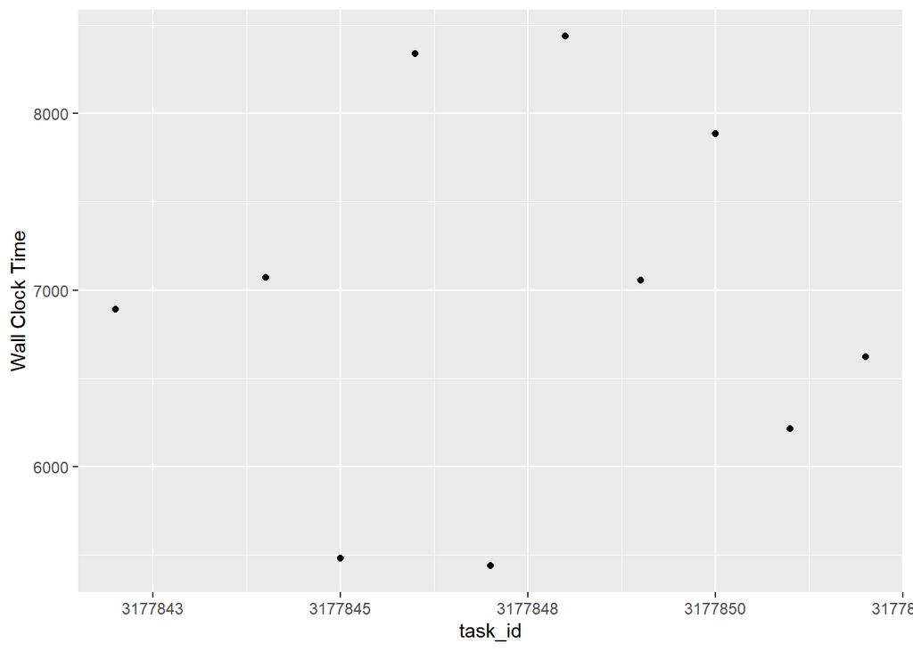

```r
# Suspecious: high sd for Ookami-OSS
df <- results_num %>%
  filter(app =="enzo"&resource=="Ookami-OSS") %>%
  filter(metric %in% c("Wall Clock Time","Simulation Speed","Energy","Power(Max)","Power(Mean)")) %>%
           select(-units,-metric_type,-app) %>%
  spread(metric,value) %>% arrange(task_id)
ggplot(df,aes(x=task_id,y=`Wall Clock Time`)) + geom_point()
```

```r
# outcome: it looks ok
```

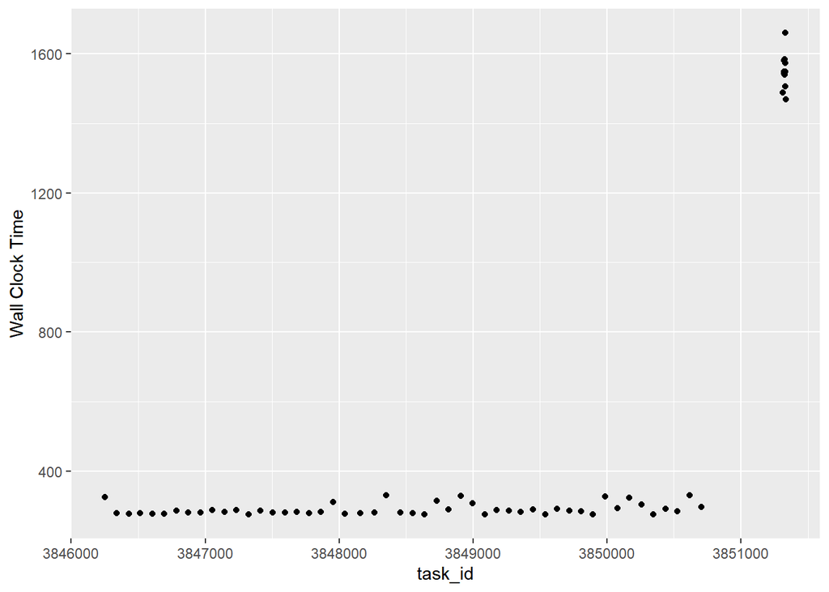

```r
# Suspecious: several app version and high mean for one of them on UBHPC_32core_SKX
df <- results_num %>%
  filter(app =="enzo"&resource=="UBHPC_32core") %>%
  filter(metric %in% c("Wall Clock Time","Simulation Speed","Energy","Power(Max)","Power(Mean)")) %>%
           select(-units,-metric_type,-app) %>%
  spread(metric,value) %>% arrange(task_id)
ggplot(df,aes(x=task_id,y=`Wall Clock Time`)) + geom_point()
```

```r
# outcome: i think old one is the one I made manually and slow is with spack and opt=debug
```

```r
results_enzo <-
  results_num %>%
  filter(app =="enzo") %>%
  filter(metric %in% c("Wall Clock Time","Simulation Speed","Energy","Power(Max)","Power(Mean)")) %>%
  left_join(app_version, by=c("resource", "task_id")) %>%
  select(-units,-metric_type,-app) %>%
  spread(metric,value) %>%
  mutate(PowerDer=Energy/`Wall Clock Time`,Power=`Power(Mean)`) %>%
  mutate(Power=ifelse(is.na(Power),`Power(Max)`,Power)) %>%
  mutate(Power=ifelse(is.na(Power),`PowerDer`,Power)) %>%
  select(-`Power(Max)`,-`Power(Mean)`,-PowerDer) %>%
  #filter(!(resource %in% c('Ookami-Fujitsu','Ookami-OSS') & is.na(Power))) %>%
  # estimate for azure-altra-64 is 300 (from ampere presentation)-(210-180) (tdp difference)
  mutate(Power=ifelse(resource==c('azure-altra-64'),300-(210-180),Power)) %>%
  # estimate for ookami is 110
  # mutate(Power=ifelse(resource %in% ookami_all,110,Power)) %>%
  mutate(Energy=ifelse(is.na(Energy),Power*`Wall Clock Time`,Energy)) %>%
  mutate(Energy2=Power*`Wall Clock Time`) %>%
  mutate(kwh_per_jobs=Energy2/3600/1000) %>% # J = W*s=W/3600 Wh
  mutate(jobs_per_kwh=1/kwh_per_jobs) %>%
  left_join(resource_spec[,c("resource","cores_per_node")], by=c("resource")) %>%
  mutate(cores=nodes*cores_per_node) %>%
  group_by(resource,app_version,cores) %>%
  summarise(
    `Wall Clock Time (Mean)`=sprintf("%.1f", mean(`Wall Clock Time`)/60),
    `Wall Clock Time (St.Dev.)`=sprintf("± %.1f", sd(`Wall Clock Time`)/60),
    Power=sci_notation_calc(Power,digits=0),
    `jobs_per_kwh (Mean)`=sprintf("%.1f", mean(`jobs_per_kwh`)),
    `jobs_per_kwh (St.Dev.)`=sprintf("± %.1f", sd(`jobs_per_kwh`)),
    n=n(), .groups="drop") %>%
  left_join(resource_spec, by=c("resource")) %>%
  mutate(resource=factor(resource,level=names(ppn))) %>%
  arrange(resource) %>%
  select("cpu", "cores",
"Wall Clock Time (Mean)", "Wall Clock Time (St.Dev.)", "Power", "jobs_per_kwh (Mean)", "jobs_per_kwh (St.Dev.)",
"n",
"app_version", "formal_name", "resource",  "release_date", "nominal_freq")

results_enzo %>% write.csv("out/enzo.csv")
results_enzo %>% kable()
```

| cpu | cores | Wall Clock Time (Mean) | Wall Clock Time (St.Dev.) | Power | jobs_per_kwh (Mean) | jobs_per_kwh (St.Dev.) | n | app_version | formal_name | resource | release_date | nominal_freq |
| --- | --- | --- | --- | --- | --- | --- | --- | --- | --- | --- | --- | --- |
| ARM Futjitsu A64FX, SVE 512b (SBU-Ookami, GCC) | 48 | 115.7 | ± 17.7 | 112 ± 7 | 4.7 | ± 0.5 | 10 | unknown | Ookami-OSS | Ookami-OSS | 2019? | 1.8 |
| ARM Amazon Graviton 2, Neoverse N1 (AWS) | 48 | 23.6 | ± 1.1 | NA | NA | ± NA | 12 | unknown | Amazon-Graviton2-48 | amazon-graviton2-48 | Nov-2019 | 2.6 |
| ARM Amazon Graviton 3, Neoverse V1, SVE 256b (AWS) | 48 | 17.0 | ± 1.2 | NA | NA | ± NA | 11 | unknown | Amazon-Graviton3-48 | amazon-graviton3-48 | Nov-2021 | 2.5 |
| ARM Amazon Graviton 3, Neoverse V1, SVE 256b (AWS) | 64 | 13.2 | ± 0.7 | NA | NA | ± NA | 20 | unknown | Amazon-Graviton3-64 | amazon-graviton3-64 | Nov-2021 | 2.5 |
| ARM Ampere Altra, Neoverse N1 (Azure) | 48 | 21.0 | ± 1.0 | NA | NA | ± NA | 11 | unknown | Google-T2A-48 | google-tau-t2a-48 | March-2021 | Up to 3.0 |
| ARM Ampere Altra, Neoverse N1 (Azure) | 64 | 15.9 | ± 0.8 | 270 ± 0 | 14.0 | ± 0.7 | 20 | unknown | Azure-Altra-64 | azure-altra-64 | March-2021 | Up to 3.0 |
| x86 AMD EPYC 7742 Zen2(Rome), AVX2 (PSC-Bridges-2) | 128 | 7.1 | ± 0.4 | NA | NA | ± NA | 20 | unknown | PSC Bridges-2 | Bridges-2 | Mid-2019 | 2.25 |
| x86 AMD EPYC 7742 Zen2(Rome), AVX2 (SDSC Expanse) | 128 | 6.6 | ± 0.4 | NA | NA | ± NA | 20 | unknown | SDSC Expanse | Expanse | Mid-2019 | 2.25 |
| x86 AMD EPYC 7763 Zen3(Milan), AVX2 (Purdue Anvil) | 128 | 6.9 | ± 0.3 | NA | NA | ± NA | 20 | unknown | Purdue Anvil | Anvil | March-2021 | 2.45 |
| x86 Intel Xeon Phi 7250, KNL, AVX512 (TACC-Stampede 2) | 68 | 14.7 | ± 0.3 | NA | NA | ± NA | 20 | Branch:stable Revision:1616af64765d | TACC-Stampede 2 KNL | stampede2-knl | Q2 2016 | 1.4 |
| x86 Intel Xeon Plat. 8160, Skylake-X, AVX512 (TACC-Stampede 2) | 48 | 4.2 | ± 0.1 | NA | NA | ± NA | 20 | unknown | TACC-Stampede 2 SKX | stampede2-skx | Q3 2017 | 2.1 |
| x86 Intel Xeon Gold 6130, Skylake-X, AVX512 (UB-HPC) | 32 | 4.8 | ± 0.3 | 338 ± 31 | 37.1 | ± 3.9 | 50 | Branch:stable Revision:1616af64765d+ | UBHPC_32core_SKX | UBHPC_32core | Q3 2017 | 2.1/3.7 |
| x86 Intel Xeon Gold 6130, Skylake-X, AVX512 (UB-HPC) | 32 | 25.8 | ± 0.9 | 379 ± 26 | 6.2 | ± 0.4 | 11 | unknown | UBHPC_32core_SKX | UBHPC_32core | Q3 2017 | 2.1/3.7 |
| x86 Intel Xeon Gold 6330, Ice Lake, AVX512 (UB-HPC) | 56 | 15.5 | ± 0.6 | 559 ± 34 | 6.9 | ± 0.4 | 11 | unknown | UBHPC_56core | UBHPC_56core | Q2 2021 | 2.0 |

here we have inconsistent Wall Clock Time

## OpenFOAM

```r
# Merge
openfoam2 <- openfoam %>%
  rename(task_id=id,app_version=config) %>%
  mutate(
    metric=recode(metric,
                  mashing='Snappy run-time',
                  solver='Solver run-time',
                  runtime='Wall Clock Time'),
    resource=recode(
      resource,
      `Amazon-Graviton3-48`="amazon-graviton3-48",
      `Amazon-Graviton2-48`="amazon-graviton2-48",
      `Google-Ampere-Altra`="google-tau-t2a-48",
      `Stampede2-SKX`="stampede2-skx",
      `Stampede2-ICX`="stampede2-icx"),
    units="Seconds",
    app="openfoam",
    nodes=1,
    metric_type="statistic"
    ) %>%
  arrange(resource,app_version,cores,task_id,metric) %>%
  select("resource", "app", "nodes", "cores", "task_id", "metric_type",
         "metric", "value", "units")  %>%
  filter(!resource %in% ookami_all)
```

```r
results_openfoam <-
  results_num %>%
  filter(app =="openfoam") %>%
  filter(metric %in% c("Wall Clock Time",'Snappy run-time','Solver run-time',"Energy","Power(Max)","Power(Mean)")) %>%
  bind_rows(openfoam2) %>%
  left_join(app_version, by=c("resource", "task_id")) %>%
  select(-units,-metric_type,-app) %>%
  spread(metric,value) %>%
  filter(!is.na(`Solver run-time`)) %>%
  mutate(PowerDer=Energy/`Wall Clock Time`,Power=`Power(Mean)`) %>%
  mutate(Power=ifelse(is.na(Power),`Power(Max)`,Power)) %>%
  mutate(Power=ifelse(is.na(Power),`PowerDer`,Power)) %>%
  select(-`Power(Max)`,-`Power(Mean)`,-PowerDer) %>%
  #filter(!(resource %in% c('Ookami-Fujitsu','Ookami-OSS') & is.na(Power))) %>%
  # estimate for azure-altra-64 is 300 (from ampere presentation)-(210-180) (tdp difference)
  mutate(Power=ifelse(resource==c('azure-altra-64'),300-(210-180),Power)) %>%
  # estimate for ookami is 110
  # mutate(Power=ifelse(resource %in% ookami_all,110,Power)) %>%
  mutate(Energy=ifelse(is.na(Energy),Power*`Wall Clock Time`,Energy)) %>%
  mutate(Energy2=Power*`Wall Clock Time`) %>%
  mutate(kwh_per_jobs=Energy2/3600/1000) %>% # J = W*s=W/3600 Wh
  mutate(jobs_per_kwh=1/kwh_per_jobs) %>%
  left_join(resource_spec[,c("resource","cores_per_node")], by=c("resource")) %>%
  mutate(cores=nodes*cores_per_node) %>%
  group_by(resource,app_version,cores) %>%
  summarise(
    `Wall Clock Time (Mean)`=sprintf("%.1f", mean(`Wall Clock Time`)/60),
    `Wall Clock Time (St.Dev.)`=sprintf("± %.1f", sd(`Wall Clock Time`)/60),
    `Meshing Time (Mean)`=sprintf("%.1f", mean(`Snappy run-time`)/60),
    `Meshing Time (St.Dev.)`=sprintf("± %.1f", sd(`Snappy run-time`)/60),
    `Solver Time (Mean)`=sprintf("%.1f", mean(`Solver run-time`)/60),
    `Solver Time (St.Dev.)`=sprintf("± %.1f", sd(`Solver run-time`)/60),
    Power=sci_notation_calc(Power,digits=0),
    `jobs_per_kwh (Mean)`=sprintf("%.1f", mean(`jobs_per_kwh`)),
    `jobs_per_kwh (St.Dev.)`=sprintf("± %.1f", sd(`jobs_per_kwh`)),
    n=n(), .groups="drop") %>%
  left_join(resource_spec, by=c("resource")) %>%
  mutate(resource=factor(resource,level=names(ppn))) %>%
  arrange(resource) %>%
  select("formal_name", "cpu", "cores",
"Wall Clock Time (Mean)", "Wall Clock Time (St.Dev.)",
`Meshing Time (Mean)`, `Meshing Time (St.Dev.)`,`Solver Time (Mean)`,`Solver Time (St.Dev.)`,"Power", "jobs_per_kwh (Mean)", "jobs_per_kwh (St.Dev.)",
"n",
"app_version", "resource",  "release_date", "nominal_freq")


results_openfoam %>% write.csv("out/openfoam.csv")
results_openfoam %>% kable()
```

| formal_name | cpu | cores | Wall Clock Time (Mean) | Wall Clock Time (St.Dev.) | Meshing Time (Mean) | Meshing Time (St.Dev.) | Solver Time (Mean) | Solver Time (St.Dev.) | Power | jobs_per_kwh (Mean) | jobs_per_kwh (St.Dev.) | n | app_version | resource | release_date | nominal_freq |
| --- | --- | --- | --- | --- | --- | --- | --- | --- | --- | --- | --- | --- | --- | --- | --- | --- |
| Ookami-OSS | ARM Futjitsu A64FX, SVE 512b (SBU-Ookami, GCC) | 48 | 28.4 | ± 0.9 | 14.6 | ± 0.9 | 12.4 | ± 0.1 | 110 ± 7 | 19.3 | ± 1.6 | 21 | _76d719d1e6-20220624 OPENFOAM=2206 version=v2206 | Ookami-OSS | 2019? | 1.8 |
| Ookami-Fujitsu | ARM Futjitsu A64FX, SVE 512b (SBU-Ookami, FJ) | 48 | 22.4 | ± 0.3 | 8.5 | ± 0.1 | 10.9 | ± 0.2 | 111 ± 7 | 24.1 | ± 1.6 | 21 | v1812 OPENFOAM=1812 | Ookami-Fujitsu | 2019? | 1.8 |
| Amazon-Graviton2-48 | ARM Amazon Graviton 2, Neoverse N1 (AWS) | 48 | 11.9 | ± 0.3 | 3.5 | ± 0.2 | 8.0 | ± 0.1 | NA | NA | ± NA | 10 | NA | amazon-graviton2-48 | Nov-2019 | 2.6 |
| Amazon-Graviton3-48 | ARM Amazon Graviton 3, Neoverse V1, SVE 256b (AWS) | 48 | 7.1 | ± 0.2 | 2.2 | ± 0.2 | 4.7 | ± 0.0 | NA | NA | ± NA | 5 | NA | amazon-graviton3-48 | Nov-2021 | 2.5 |
| Amazon-Graviton3-64 | ARM Amazon Graviton 3, Neoverse V1, SVE 256b (AWS) | 64 | 6.8 | ± 0.1 | 2.2 | ± 0.1 | 4.4 | ± 0.1 | NA | NA | ± NA | 20 | _76d719d1e6-20220624 OPENFOAM=2206 version=v2206 | amazon-graviton3-64 | Nov-2021 | 2.5 |
| Google-T2A-48 | ARM Ampere Altra, Neoverse N1 (Azure) | 48 | 11.1 | ± 0.2 | 3.2 | ± 0.2 | 7.6 | ± 0.1 | NA | NA | ± NA | 10 | NA | google-tau-t2a-48 | March-2021 | Up to 3.0 |
| Azure-Altra-64 | ARM Ampere Altra, Neoverse N1 (Azure) | 64 | 10.9 | ± 0.4 | 3.2 | ± 0.2 | 7.2 | ± 0.2 | 270 ± 0 | 20.4 | ± 0.6 | 20 | _76d719d1e6-20220624 OPENFOAM=2206 version=v2206 | azure-altra-64 | March-2021 | Up to 3.0 |
| SDSC Expanse | x86 AMD EPYC 7742 Zen2(Rome), AVX2 (SDSC Expanse) | 128 | 9.5 | ± 1.9 | 5.6 | ± 1.4 | 3.2 | ± 1.1 | NA | NA | ± NA | 20 | NA | Expanse | Mid-2019 | 2.25 |
| Purdue Anvil | x86 AMD EPYC 7763 Zen3(Milan), AVX2 (Purdue Anvil) | 128 | 6.6 | ± 0.2 | 3.1 | ± 0.5 | 2.9 | ± 0.5 | NA | NA | ± NA | 19 | NA | Anvil | March-2021 | 2.45 |
| TACC-Stampede 2 SKX | x86 Intel Xeon Plat. 8160, Skylake-X, AVX512 (TACC-Stampede 2) | 48 | 10.7 | ± 0.4 | 3.7 | ± 0.3 | 6.4 | ± 0.1 | NA | NA | ± NA | 10 | NA | stampede2-skx | Q3 2017 | 2.1 |
| TACC-Stampede 2 ICX | x86 Intel Xeon Plat. 8380, Ice Lake, AVX512 (TACC-Stampede 2) | 80 | 6.8 | ± 0.3 | 2.6 | ± 0.2 | 3.7 | ± 0.3 | NA | NA | ± NA | 20 | NA | stampede2-icx | Q2 2021 | 2.3 |
| UBHPC_32core_SKX | x86 Intel Xeon Gold 6130, Skylake-X, AVX512 (UB-HPC) | 32 | 13.2 | ± 0.8 | 4.1 | ± 0.4 | 7.7 | ± 0.1 | 375 ± 35 | 12.3 | ± 1.0 | 23 | _76d719d1e6-20220624 OPENFOAM=2206 version=v2206 | UBHPC_32core | Q3 2017 | 2.1/3.7 |
| UBHPC_56core | x86 Intel Xeon Gold 6330, Ice Lake, AVX512 (UB-HPC) | 56 | 8.9 | ± 0.5 | 2.8 | ± 0.3 | 4.7 | ± 0.2 | 505 ± 34 | 13.4 | ± 0.9 | 20 | _76d719d1e6-20220624 OPENFOAM=2206 version=v2206 | UBHPC_56core | Q2 2021 | 2.0 |

## ai_benchmark_alpha

```r
results_aibench <-
  results_num %>%
  filter(app =="ai_benchmark_alpha") %>%
  filter(metric %in% c("Wall Clock Time","AI Score","Inference Score","Training Score","Energy","Power(Max)","Power(Mean)")) %>%
  left_join(app_version, by=c("resource", "task_id")) %>%
  select(-units,-metric_type,-app) %>%
  spread(metric,value) %>%
  mutate(`Power(Mean)`=NA) %>%
  mutate(PowerDer=Energy/`Wall Clock Time`,Power=`Power(Mean)`) %>%
  mutate(Power=ifelse(is.na(Power),`Power(Max)`,Power)) %>%
  mutate(Power=ifelse(is.na(Power),`PowerDer`,Power)) %>%
  select(-`Power(Max)`,-`Power(Mean)`,-PowerDer) %>%
  filter(!(resource %in% ookami_all & is.na(Power))) %>%
  # estimate for azure-altra-64 is 300 (from ampere presentation)-(210-180) (tdp difference)
  mutate(Power=ifelse(resource==c('azure-altra-64'),300-(210-180),Power)) %>%
  # estimate for ookami is 110
  # mutate(Power=ifelse(resource %in% ookami_all,110,Power)) %>%
  mutate(Energy=ifelse(is.na(Energy),Power*`Wall Clock Time`,Energy)) %>%
  mutate(Energy2=Power*`Wall Clock Time`) %>%
  mutate(aiscore_per_w=`AI Score`/Power) %>%
  left_join(resource_spec[,c("resource","cores_per_node")], by=c("resource")) %>%
  mutate(cores=nodes*cores_per_node) %>%
  group_by(resource,app_version,cores) %>%
  summarise(
    `Wall Clock Time (Mean)`=round(mean(`Wall Clock Time`),1),
    `Wall Clock Time (St.Dev.)`=round(sd(`Wall Clock Time`),1),
    `AI Score (Mean)`=round(mean(`AI Score`),0),
    `AI Score (St.Dev.)`=sprintf("± %.0f", sd(`AI Score`)),
    `Inference Score (Mean)`=round(mean(`Inference Score`),0),
    `Inference Score (St.Dev.)`=sprintf("± %.0f", sd(`Inference Score`)),
    `Training Score (Mean)`=round(mean(`Training Score`),0),
    `Training Score (St.Dev.)`=sprintf("± %.0f", sd(`Training Score`)),
    Power=sci_notation_calc(Power,digits=0),
    `aiscore_per_w (Mean)`=sprintf("%.1f", mean(`aiscore_per_w`)),
    `aiscore_per_w (St.Dev.)`=sprintf("± %.1f", sd(`aiscore_per_w`)),
    n=n(), .groups="drop") %>%
  left_join(resource_spec, by=c("resource")) %>%
  mutate(resource=factor(resource,level=names(ppn))) %>%
  arrange(resource) %>%
  select("cpu", "cores",

"AI Score (Mean)", "AI Score (St.Dev.)",
"Inference Score (Mean)", "Inference Score (St.Dev.)", "Training Score (Mean)",
"Training Score (St.Dev.)",
"Power", "aiscore_per_w (Mean)", "aiscore_per_w (St.Dev.)",
"n", "formal_name",
"Wall Clock Time (Mean)", "Wall Clock Time (St.Dev.)",
"app_version", "resource",  "release_date", "nominal_freq")

#mutate(speed=sci_notation(average,stdev,n,0),per_core=round(average/cores,2)) %>%

results_aibench %>% write.csv("out/aibench.csv")
results_aibench %>% kable()
```

| cpu | cores | AI Score (Mean) | AI Score (St.Dev.) | Inference Score (Mean) | Inference Score (St.Dev.) | Training Score (Mean) | Training Score (St.Dev.) | Power | aiscore_per_w (Mean) | aiscore_per_w (St.Dev.) | n | formal_name | Wall Clock Time (Mean) | Wall Clock Time (St.Dev.) | app_version | resource | release_date | nominal_freq |
| --- | --- | --- | --- | --- | --- | --- | --- | --- | --- | --- | --- | --- | --- | --- | --- | --- | --- | --- |
| ARM Futjitsu A64FX, SVE 512b (SBU-Ookami) | 48 | 1034 | ± 3 | 535 | ± 2 | 499 | ± 2 | 111 ± 7 | 9.4 | ± 0.6 | 20 | Ookami-Bin | 2099.0 | 7.2 | 0.1.2 | Ookami-Bin | 2019? | 1.8 |
| ARM Amazon Graviton 2, Neoverse N1 (AWS) | 48 | 3030 | ± 12 | 1676 | ± 7 | 1355 | ± 6 | NA | NA | ± NA | 12 | Amazon-Graviton2-48 | 1217.2 | 5.1 | 0.1.2 | amazon-graviton2-48 | Nov-2019 | 2.6 |
| ARM Amazon Graviton 3, Neoverse V1, SVE 256b (AWS) | 48 | 4581 | ± 12 | 2407 | ± 10 | 2174 | ± 8 | NA | NA | ± NA | 11 | Amazon-Graviton3-48 | 1012.1 | 37.2 | 0.1.2 | amazon-graviton3-48 | Nov-2021 | 2.5 |
| ARM Amazon Graviton 3, Neoverse V1, SVE 256b (AWS) | 64 | 4850 | ± 31 | 2708 | ± 21 | 2143 | ± 13 | NA | NA | ± NA | 20 | Amazon-Graviton3-64 | 973.4 | 4.3 | 0.1.2 | amazon-graviton3-64 | Nov-2021 | 2.5 |
| ARM Ampere Altra, Neoverse N1 (Azure) | 48 | 3177 | ± 15 | 1803 | ± 10 | 1375 | ± 6 | NA | NA | ± NA | 11 | Google-T2A-48 | 1179.2 | 5.2 | 0.1.2 | google-tau-t2a-48 | March-2021 | Up to 3.0 |
| ARM Ampere Altra, Neoverse N1 (Azure) | 64 | 3214 | ± 20 | 1977 | ± 15 | 1238 | ± 6 | 270 ± 0 | 11.9 | ± 0.1 | 20 | Azure-Altra-64 | 1184.2 | 6.7 | 0.1.2 | azure-altra-64 | March-2021 | Up to 3.0 |
| x86 AMD EPYC 7742 Zen2(Rome), AVX2 (SDSC Expanse) | 128 | 2696 | ± 17 | 1761 | ± 14 | 936 | ± 9 | NA | NA | ± NA | 11 | SDSC Expanse | 1190.5 | 9.9 | 0.1.2 | Expanse | Mid-2019 | 2.25 |
| x86 AMD EPYC 7763 Zen3(Milan), AVX2 (Purdue Anvil) | 128 | 3079 | ± 26 | 1992 | ± 16 | 1087 | ± 13 | NA | NA | ± NA | 11 | Purdue Anvil | 1098.7 | 4.7 | 0.1.2 | Anvil | March-2021 | 2.45 |
| x86 Intel Xeon Plat. 8160, Skylake-X, AVX512 (TACC-Stampede 2) | 48 | 3606 | ± 20 | 2292 | ± 18 | 1314 | ± 4 | NA | NA | ± NA | 11 | TACC-Stampede 2 SKX | 1100.7 | 5.3 | 0.1.2 | stampede2-skx | Q3 2017 | 2.1 |
| x86 Intel Xeon Plat. 8380, Ice Lake, AVX512 (TACC-Stampede 2) | 80 | 8805 | ± 27 | 3725 | ± 20 | 5081 | ± 14 | NA | NA | ± NA | 11 | TACC-Stampede 2 ICX | 758.9 | 3.4 | 0.1.2 | stampede2-icx | Q2 2021 | 2.3 |
| x86 Intel Xeon Gold 6130, Skylake-X, AVX512 (UB-HPC) | 32 | 3233 | ± 253 | 1941 | ± 165 | 1292 | ± 88 | 403 ± 14 | 8.0 | ± 0.5 | 11 | UBHPC_32core_SKX | 1269.8 | 287.3 | 0.1.2 | UBHPC_32core | Q3 2017 | 2.1/3.7 |
| x86 Intel Xeon Gold 6330, Ice Lake, AVX512 (UB-HPC) | 56 | 10197 | ± 53 | 4398 | ± 31 | 5799 | ± 29 | 543 ± 33 | 18.9 | ± 1.2 | 12 | UBHPC_56core | 772.4 | 12.0 | 0.1.2 | UBHPC_56core | Q2 2021 | 2.0 |
| x86 Intel Xeon Gold 6130, NVIDIA V100x2 (UB-HPC) | 32 | 32628 | ± 433 | 15656 | ± 278 | 16972 | ± 163 | 379 ± 34 | 86.8 | ± 8.3 | 11 | UBHPC_32core_SKX_ICC | 683.0 | 281.9 | 0.1.2 | UBHPC_32core_V100 | Q3 2017 | 2.1/3.7 |
| x86 Intel Xeon Gold 6330, NVIDIA A100x2 (UB-HPC) | 56 | 59323 | ± 378 | 29691 | ± 290 | 29631 | ± 152 | 561 ± 69 | 107.2 | ± 13.6 | 11 | UBHPC_56core_A100 | 506.5 | 8.8 | 0.1.2 | UBHPC_56core_A100 | Q2 2021 | 2.0 |

# Benchmarks

## HPCC

```r
results_hpcc <-
  results_num %>%
  filter(app =="hpcc") %>%
  mutate(metric=recode(
    metric,
    `Average Double-Precision General Matrix Multiplication (DGEMM) Floating-Point Performance`="Mat. Mult.",
    `High Performance LINPACK Floating-Point Performance`="LINPACK",
    `Fast Fourier Transform (FFTW) Floating-Point Performance`="FFT"
    )) %>%
  filter(metric %in% c("Wall Clock Time","Mat. Mult.","LINPACK","FFT","Energy","Power(Max)","Power(Mean)")) %>%
  left_join(app_version, by=c("resource", "task_id")) %>%
  select(-units,-metric_type,-app) %>%
  spread(metric,value) %>%
  mutate(`Power(Mean)`=NA) %>%
  mutate(PowerDer=Energy/`Wall Clock Time`,Power=`Power(Mean)`) %>%
  mutate(Power=ifelse(is.na(Power),`Power(Max)`,Power)) %>%
  mutate(Power=ifelse(is.na(Power),`PowerDer`,Power)) %>%
  select(-`Power(Max)`,-`Power(Mean)`,-PowerDer) %>%
  #filter(!(resource %in% ookami_all & is.na(Power))) %>%
  # estimate for azure-altra-64 is 300 (from ampere presentation)-(210-180) (tdp difference)
  mutate(Power=ifelse(resource==c('azure-altra-64'),300-(210-180),Power)) %>%
  # estimate for ookami is 110
  mutate(Power=ifelse(resource %in% ookami_all,110,Power)) %>%
  mutate(Energy=ifelse(is.na(Energy),Power*`Wall Clock Time`,Energy)) %>%
  mutate(Energy2=Power*`Wall Clock Time`) %>%
  mutate(kwh_per_jobs=Energy2/3600/1000) %>% # J = W*s=W/3600 Wh
  mutate(jobs_per_kwh=1/kwh_per_jobs) %>%
  left_join(resource_spec[,c("resource","cores_per_node")], by=c("resource")) %>%
  mutate(cores=nodes*cores_per_node) %>%
  group_by(resource,app_version,cores) %>%
  summarise(
    `Wall Clock Time (Mean)`=round(mean(`Wall Clock Time`),1),
    `Wall Clock Time (St.Dev.)`=paste0("± ", round(sd(`Wall Clock Time`),1)),
    `Mat. Mult. (Mean)`=sprintf("%.1f", mean(`Mat. Mult.`)/1000),
    `Mat. Mult. (St.Dev.)`=sprintf("± %.1f", sd(`Mat. Mult.`)/1000),
    `LINPACK (Mean)`=round(mean(`LINPACK`)/1000,0),
    `LINPACK (St.Dev.)`=paste0("± ", round(sd(`LINPACK`)/1000,0)),
    `FFT (Mean)`=sprintf("%.1f", mean(`FFT`/1000)),
    `FFT (St.Dev.)`=sprintf("± %.1f", sd(`FFT`/1000)),
    Power=sci_notation_calc(Power,digits=0),
    `jobs_per_kwh (Mean)`=round(mean(`jobs_per_kwh`),0),
    `jobs_per_kwh (St.Dev.)`=paste0("± ", round(sd(`jobs_per_kwh`),0)),
    n=n(), .groups="drop") %>%
  left_join(resource_spec, by=c("resource")) %>%
  mutate(resource=factor(resource,level=names(ppn))) %>%
  arrange(resource) %>%
  select("cpu", "cores",
 "Mat. Mult. (Mean)", "Mat. Mult. (St.Dev.)",
"LINPACK (Mean)", "LINPACK (St.Dev.)", "FFT (Mean)", "FFT (St.Dev.)",
"Power", "jobs_per_kwh (Mean)", "jobs_per_kwh (St.Dev.)", "n",
"Wall Clock Time (Mean)",
"Wall Clock Time (St.Dev.)",
"app_version", "formal_name",  "resource",  "release_date", "nominal_freq"
)
results_hpcc %>%  write.csv("out/hpcc.csv")
results_hpcc %>% kable()
```

| cpu | cores | Mat. Mult. (Mean) | Mat. Mult. (St.Dev.) | LINPACK (Mean) | LINPACK (St.Dev.) | FFT (Mean) | FFT (St.Dev.) | Power | jobs_per_kwh (Mean) | jobs_per_kwh (St.Dev.) | n | Wall Clock Time (Mean) | Wall Clock Time (St.Dev.) | app_version | formal_name | resource | release_date | nominal_freq |
| --- | --- | --- | --- | --- | --- | --- | --- | --- | --- | --- | --- | --- | --- | --- | --- | --- | --- | --- |
| ARM Futjitsu A64FX, SVE 512b (SBU-Ookami, GCC) | 48 | 28.4 | ± 0.1 | 828 | ± 27 | 6.2 | ± 0.7 | 110 ± 0 | 560 | ± 28 | 60 | 58.6 | ± 3.6 | 1.5.0f | Ookami-OSS | Ookami-OSS | 2019? | 1.8 |
| ARM Futjitsu A64FX, SVE 512b (SBU-Ookami, FJ) | 48 | 41.2 | ± 0.2 | 1177 | ± 19 | 24.4 | ± 0.9 | 110 ± 0 | 185 | ± 6 | 60 | 177.2 | ± 5.8 | 1.5.0f | Ookami-Fujitsu | Ookami-Fujitsu | 2019? | 1.8 |
| ARM Futjitsu A64FX, SVE 512b (SBU-Ookami, ARM) | 48 | 34.4 | ± 1.8 | 884 | ± 72 | 0.3 | ± 0.0 | 110 ± 0 | 335 | ± 19 | 60 | 98.2 | ± 6.6 | 1.5.0f | Ookami-ARM | Ookami-ARM | 2019? | 1.8 |
| ARM Futjitsu A64FX, SVE 512b (SBU-Ookami, Cray) | 48 | 19.1 | ± 3.7 | 758 | ± 149 | 6.8 | ± 0.6 | 110 ± 0 | 204 | ± 11 | 60 | 160.9 | ± 10 | 1.5.0f | Ookami-Cray | Ookami-Cray | 2019? | 1.8 |
| ARM Cavium ThunderX2 (SBU-Ookami) | 64 | 11.6 | ± 2.1 | 522 | ± 106 | 33.5 | ± 3.7 | NA | NA | ± NA | 14 | 78.2 | ± 7.7 | 1.5.0f | ThunderX2 | ThunderX2 | 2018 | 2.0-2.5? |
| ARM Amazon Graviton 2, Neoverse N1 (AWS) | 48 | 17.0 | ± 0.0 | 682 | ± 1 | 27.1 | ± 0.6 | NA | NA | ± NA | 20 | 55.1 | ± 1.1 | 1.5.0f | Amazon-Graviton2-48 | amazon-graviton2-48 | Nov-2019 | 2.6 |
| ARM Amazon Graviton 3, Neoverse V1, SVE 256b (AWS) | 48 | 18.9 | ± 0.3 | 776 | ± 10 | 55.4 | ± 0.5 | NA | NA | ± NA | 20 | 42.5 | ± 1.6 | 1.5.0f | Amazon-Graviton3-48 | amazon-graviton3-48 | Nov-2021 | 2.5 |
| ARM Amazon Graviton 3, Neoverse V1, SVE 256b (AWS) | 64 | 18.1 | ± 0.0 | 965 | ± 1 | 71.0 | ± 0.7 | NA | NA | ± NA | 20 | 39.2 | ± 0.9 | 1.5.0f | Amazon-Graviton3-64 | amazon-graviton3-64 | Nov-2021 | 2.5 |
| ARM Ampere Altra, Neoverse N1 (Azure) | 48 | 17.0 | ± 0.0 | 675 | ± 17 | 26.5 | ± 0.4 | NA | NA | ± NA | 11 | 52.1 | ± 1.9 | 1.5.0f | Google-T2A-48 | google-tau-t2a-48 | March-2021 | Up to 3.0 |
| ARM Ampere Altra, Neoverse N1 (Azure) | 48 | 17.2 | ± 0.0 | 691 | ± 18 | 26.8 | ± 0.7 | NA | NA | ± NA | 11 | 42.3 | ± 6.3 | 1.5.0f | Azure-Altra-48 | azure-altra-48 | March-2021 | Up to 3.0 |
| ARM Ampere Altra, Neoverse N1 (Azure) | 64 | 16.2 | ± 0.0 | 850 | ± 4 | 33.1 | ± 1.1 | 270 ± 0 | 314 | ± 23 | 20 | 42.8 | ± 3.4 | 1.5.0f | Azure-Altra-64 | azure-altra-64 | March-2021 | Up to 3.0 |
| x86 AMD EPYC 7742 Zen2(Rome), AVX2 (PSC-Bridges-2) | 128 | 20.5 | ± 0.7 | 1895 | ± 42 | 50.3 | ± 0.3 | NA | NA | ± NA | 20 | 23.9 | ± 7.1 | 1.5.0f | PSC Bridges-2 | Bridges-2 | Mid-2019 | 2.25 |
| x86 AMD EPYC 7742 Zen2(Rome), AVX2 (SDSC Expanse) | 128 | 25.0 | ± 1.4 | 1721 | ± 47 | 71.8 | ± 2.0 | NA | NA | ± NA | 20 | 49.0 | ± 1 | 1.5.0f | SDSC Expanse | Expanse | Mid-2019 | 2.25 |
| x86 AMD EPYC 7763 Zen3(Milan), AVX2 (Purdue Anvil) | 128 | 23.8 | ± 1.6 | 2176 | ± 100 | 54.7 | ± 4.8 | NA | NA | ± NA | 20 | 36.9 | ± 0.9 | 1.5.0f | Purdue Anvil | Anvil | March-2021 | 2.45 |
| x86 Intel Xeon Phi 7250, KNL, AVX512 (TACC-Stampede 2) | 68 | 5.0 | ± 0.3 | 986 | ± 8 | 46.5 | ± 0.7 | NA | NA | ± NA | 20 | 174.3 | ± 0.7 | 1.5.0f | TACC-Stampede 2 KNL | stampede2-knl | Q2 2016 | 1.4 |
| x86 Intel Xeon Plat. 8160, Skylake-X, AVX512 (TACC-Stampede 2) | 48 | 44.2 | ± 1.7 | 1158 | ± 34 | 35.8 | ± 1.9 | NA | NA | ± NA | 20 | 78.4 | ± 24.7 | 1.5.0f | TACC-Stampede 2 SKX | stampede2-skx | Q3 2017 | 2.1 |
| x86 Intel Xeon Plat. 8380, Ice Lake, AVX512 (TACC-Stampede 2) | 80 | 47.8 | ± 0.6 | 1713 | ± 5 | 76.4 | ± 2.0 | NA | NA | ± NA | 12 | 86.2 | ± 0.9 | 1.5.0f | TACC-Stampede 2 ICX | stampede2-icx | Q2 2021 | 2.3 |
| x86 Intel Xeon Gold 6130, Skylake-X, AVX512 (UB-HPC) | 32 | 48.0 | ± 2.0 | 997 | ± 54 | 50.9 | ± 1.9 | 345 ± 31 | 74 | ± 6 | 53 | 142.1 | ± 1.1 | 1.4.2f | UBHPC_32core_SKX | UBHPC_32core | Q3 2017 | 2.1/3.7 |
| x86 Intel Xeon Gold 6330, Ice Lake, AVX512 (UB-HPC) | 56 | 49.3 | ± 1.1 | 1396 | ± 37 | 47.9 | ± 0.7 | 588 ± 64 | 109 | ± 12 | 12 | 57.2 | ± 3 | 1.5.0f | UBHPC_56core | UBHPC_56core | Q2 2021 | 2.0 |
| x86 Intel Xeon Gold 6330, Ice Lake, AVX512 (UB-HPC) | 56 | 50.8 | ± 1.0 | 1399 | ± 13 | 28.2 | ± 0.3 | 501 ± 107 | 299 | ± 71 | 12 | 25.2 | ± 0.6 | 1.5.0f | UBHPC_56core_ICC | UBHPC_56core_ICC | Q2 2021 | 2.0 |

# Energy Plot.

```r
eo <- readr::read_csv("data/ookami_power_openfoam.csv", show_col_types = FALSE)
eo$t <- eo$t - eo$t[1]
eo$Resource <- "Ookami, Fujitsu A64FX"

eu <- readr::read_csv("data/ubhpc_power_openfoam.csv", show_col_types = FALSE)
eu$t <- as.numeric(eu$t - eu$t[1])
eu$Resource <- "UB-HPC, Intel Xeon Gold 6330"

df <- bind_rows(eu,eo) %>% rename("t, seconds"=t)
df  %>% kable()
```

| t, seconds | Power, W | Resource |
| --- | --- | --- |
| 0 | 368 | UB-HPC, Intel Xeon Gold 6330 |
| 15 | 368 | UB-HPC, Intel Xeon Gold 6330 |
| 30 | 369 | UB-HPC, Intel Xeon Gold 6330 |
| 45 | 369 | UB-HPC, Intel Xeon Gold 6330 |
| 60 | 369 | UB-HPC, Intel Xeon Gold 6330 |
| 75 | 369 | UB-HPC, Intel Xeon Gold 6330 |
| 90 | 369 | UB-HPC, Intel Xeon Gold 6330 |
| 105 | 369 | UB-HPC, Intel Xeon Gold 6330 |
| 120 | 369 | UB-HPC, Intel Xeon Gold 6330 |
| 135 | 369 | UB-HPC, Intel Xeon Gold 6330 |
| 150 | 508 | UB-HPC, Intel Xeon Gold 6330 |
| 165 | 508 | UB-HPC, Intel Xeon Gold 6330 |
| 180 | 508 | UB-HPC, Intel Xeon Gold 6330 |
| 195 | 508 | UB-HPC, Intel Xeon Gold 6330 |
| 210 | 508 | UB-HPC, Intel Xeon Gold 6330 |
| 225 | 508 | UB-HPC, Intel Xeon Gold 6330 |
| 240 | 508 | UB-HPC, Intel Xeon Gold 6330 |
| 255 | 508 | UB-HPC, Intel Xeon Gold 6330 |
| 270 | 630 | UB-HPC, Intel Xeon Gold 6330 |
| 285 | 630 | UB-HPC, Intel Xeon Gold 6330 |
| 300 | 630 | UB-HPC, Intel Xeon Gold 6330 |
| 315 | 630 | UB-HPC, Intel Xeon Gold 6330 |
| 330 | 630 | UB-HPC, Intel Xeon Gold 6330 |
| 345 | 630 | UB-HPC, Intel Xeon Gold 6330 |
| 360 | 630 | UB-HPC, Intel Xeon Gold 6330 |
| 375 | 630 | UB-HPC, Intel Xeon Gold 6330 |
| 390 | 633 | UB-HPC, Intel Xeon Gold 6330 |
| 405 | 633 | UB-HPC, Intel Xeon Gold 6330 |
| 420 | 633 | UB-HPC, Intel Xeon Gold 6330 |
| 435 | 633 | UB-HPC, Intel Xeon Gold 6330 |
| 450 | 633 | UB-HPC, Intel Xeon Gold 6330 |
| 465 | 633 | UB-HPC, Intel Xeon Gold 6330 |
| 480 | 633 | UB-HPC, Intel Xeon Gold 6330 |
| 495 | 633 | UB-HPC, Intel Xeon Gold 6330 |
| 510 | 388 | UB-HPC, Intel Xeon Gold 6330 |
| 525 | 388 | UB-HPC, Intel Xeon Gold 6330 |
| 540 | 388 | UB-HPC, Intel Xeon Gold 6330 |
| 555 | 388 | UB-HPC, Intel Xeon Gold 6330 |
| 0 | 107 | Ookami, Fujitsu A64FX |
| 60 | 107 | Ookami, Fujitsu A64FX |
| 120 | 107 | Ookami, Fujitsu A64FX |
| 180 | 107 | Ookami, Fujitsu A64FX |
| 240 | 107 | Ookami, Fujitsu A64FX |
| 300 | 107 | Ookami, Fujitsu A64FX |
| 360 | 107 | Ookami, Fujitsu A64FX |
| 420 | 107 | Ookami, Fujitsu A64FX |
| 480 | 107 | Ookami, Fujitsu A64FX |
| 540 | 107 | Ookami, Fujitsu A64FX |
| 600 | 107 | Ookami, Fujitsu A64FX |
| 660 | 107 | Ookami, Fujitsu A64FX |
| 720 | 107 | Ookami, Fujitsu A64FX |
| 780 | 107 | Ookami, Fujitsu A64FX |
| 840 | 107 | Ookami, Fujitsu A64FX |
| 900 | 107 | Ookami, Fujitsu A64FX |
| 960 | 107 | Ookami, Fujitsu A64FX |
| 1020 | 107 | Ookami, Fujitsu A64FX |
| 1080 | 107 | Ookami, Fujitsu A64FX |
| 1140 | 107 | Ookami, Fujitsu A64FX |
| 1200 | 107 | Ookami, Fujitsu A64FX |
| 1260 | 107 | Ookami, Fujitsu A64FX |
| 1320 | 107 | Ookami, Fujitsu A64FX |

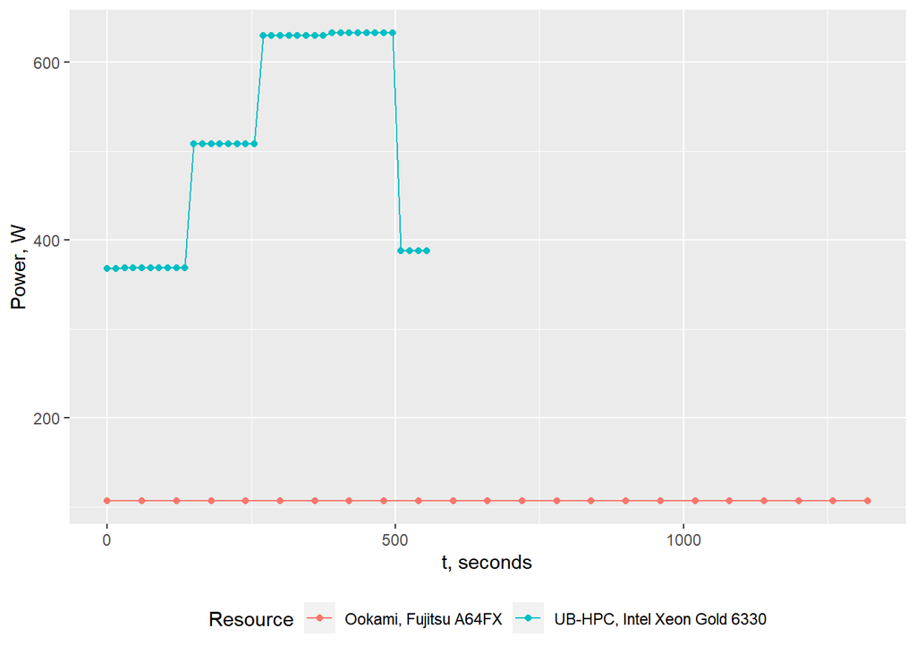

```r
ggplot(df,aes(x=`t, seconds`,y=`Power, W`, color=Resource)) + geom_point()+geom_line()+
   theme(legend.position = "bottom")
```

```r
ggsave("figs/power.pdf")
```